# Week 14 Exercises: Quarto document

Author

Affiliations

Jelmer Poelstra

[CFAES Bioinformatics Core, Ohio State University](https://go.osu.edu/bioinformatics-core)

[Dept. of Plant Pathology, Ohio State University](https://plantpath.osu.edu)

Week starts on

November 23, 2026

Page last modified

October 17, 2026

## 1 Setting up

- At https://ondemand.osc.edu, start a new RStudio session (Starting an RStudio Server session at OSC).
- Switch to your RStudio Project (Working directory and RStudio Projects)
- Create a new directory `week14` inside your RStudio Project directory using the function `dir.create("week14")`
- Create a new Quarto document (Creating a Quarto document) and save it as `w14_exercises.qmd` (inside the `week14` directory). You will write your answers to the questions below in this Quarto document.

## 2 Exercise

### 2.1 YAML header

1. Render your Quarto (.qmd) file to HTML format.
2. Add the following key–value pairs to the YAML header of your Quarto document:
- Author name
- Date
- Table of contents
3. Create nested format options in the YAML header using `format:` and `html:`, and set the `theme` to `cyborg`.

### 2.2 Code Chunks

4. Install the `palmerpenguins` package in the Console, and load the package in a code chunk of your Quarto document. Save the penguins dataset in an object called `penguin_data`.
5. Open a second code chunk, select the columns `flipper_length_mm`, `island` and `year`, and save them as a `new_penguins` object. Add a code chunk option to hide the code in the rendered file.
6. Use `penguin_data` to create a scatter plot with the `ggplot2` package of `tidyverse`. Set `flipper_length_mm` as the **x-axis** and `body_mass_g` as the **y-axis**. Refer to the `ggplot2` documentation to understand the syntax of a scatter plot. We discussed `ggplot2` in week 13.
7. Customize your figure by:
- Adding a figure caption
- Changing the figure dimensions (height and width)
- Aligning the figure to the center using chunk options
8. Render your document, download the output, and verify that it includes the scatter plot.
9. If document does not contain scatter plot, add the appropriate option in the YAML header to include figures in the HTML output.
10. Render the document again and confirm that the scatter plot is now included.

### 2.3 Text

11. Add headers of different levels above your code chunks.
12. Write a short text section describing the scatter plot you created in question 6.

## 3 Solutions

### 3.1 YAML header

**1-3.** YAML header**

*The solutions to these questions are provided in the exercise in the week 14 lecture.*

### 3.2 Code chunks

**4.** Install the `palmerpenguins` package and save the object**

```r
library(palmerpenguins)
penguin_data <- penguins
```

**5.** Select columns**

```r
## First load tidyverse to use select function
library(tidyverse)
new_penguins <- penguin_data |>
  select( flipper_length_mm, island , year)
```

**6.** Scatter plot**

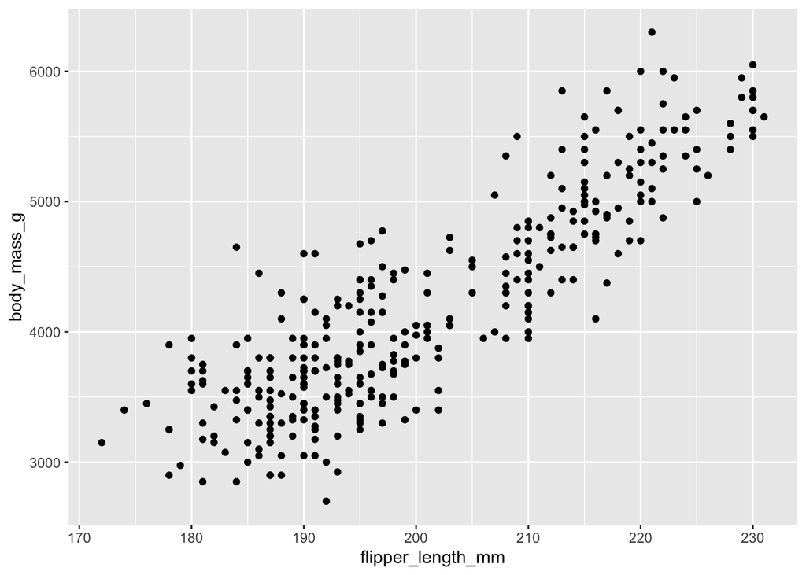

```r
library(ggplot2)
penguin_data |>
  ggplot(aes(flipper_length_mm, body_mass_g)) +
  geom_point()
```

**7.** Customize your plot**

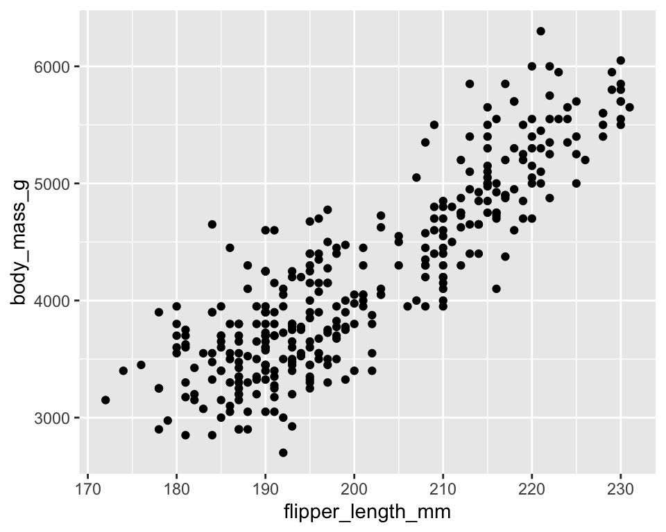

Scatter plot of palmerpenguins datasets

````markdown
```{r}
#| fig-cap: "Scatter plot of palmerpenguins datasets"
#| fig-width: 5
#| fig-height: 4
#| fig-align: center
penguin_data |>
  ggplot(aes(flipper_length_mm, body_mass_g)) +
  geom_point()
```
````

**9.** Include your plot in the HTML output**

**`embed-resources: true` in your YAML header to make your document self-contained**

Back to top